# Building *UCSC Track Hubs*

Alejandro Reyes

21 November 2023

#### Abstract

This package provides a function to reformat lists of genome coverage files, such as *bigWig* of *bam* files, into the directory structure of a *UCSC* *Track Hub* ready to be visualized in the genome browser.

#### Package

easyTrackHubs 0.0.0.9012

# 1 Input data

The main input structure is a `data.frame` containing this 5 columns:

- `sample_name`: sample label or unique identifier.
- `file_path`: path to the genome coverage files.
- `file_format`: format of the coverage file. Currently supported/tested formats are *bigWig* and *bam* files.
- `reference_genome`: *UCSC* reference genome identifier (e.g. *mm10*, *hg38*, etc).
- `data_type`: what kind of experiment is this? (e.g. *RNA-seq*, *ChIP-seq*, etc).

An example of such `data.frame` is given here:

```r
library(easyTrackHubs)
data( test_df )

package_dir <- system.file("extdata", package="easyTrackHubs", mustWork=TRUE)
bigwig_files <- list.files( package_dir, full.names=TRUE )
names(bigwig_files) <- gsub(".bigWig", "", basename(bigwig_files))

test_df$file_path <- bigwig_files[test_df$sample_name]

head(test_df)
```

```
##   sample_name file_format   target cell_type reference_genome data_type
## 1 ENCFF856TEC      bigWig  H3K27ac   HeLa-S3             hg38  ChIP-seq
## 2 ENCFF194XTD      bigWig  H3K27ac   HeLa-S3             hg38  ChIP-seq
## 3 ENCFF407CRM      bigWig  H3K27ac   HeLa-S3             hg38  ChIP-seq
## 4 ENCFF614HNF      bigWig H3K27me3   HeLa-S3             hg38  ChIP-seq
## 5 ENCFF435XFF      bigWig H3K27me3   HeLa-S3             hg38  ChIP-seq
## 6 ENCFF353ZNI      bigWig H3K27me3   HeLa-S3             hg38  ChIP-seq
##                                                                                   file_path
## 1 /home/reyesre5/R/x86_64-pc-linux-gnu-library/4.3/easyTrackHubs/extdata/ENCFF856TEC.bigWig
## 2 /home/reyesre5/R/x86_64-pc-linux-gnu-library/4.3/easyTrackHubs/extdata/ENCFF194XTD.bigWig
## 3 /home/reyesre5/R/x86_64-pc-linux-gnu-library/4.3/easyTrackHubs/extdata/ENCFF407CRM.bigWig
## 4 /home/reyesre5/R/x86_64-pc-linux-gnu-library/4.3/easyTrackHubs/extdata/ENCFF614HNF.bigWig
## 5 /home/reyesre5/R/x86_64-pc-linux-gnu-library/4.3/easyTrackHubs/extdata/ENCFF435XFF.bigWig
## 6 /home/reyesre5/R/x86_64-pc-linux-gnu-library/4.3/easyTrackHubs/extdata/ENCFF353ZNI.bigWig
```

# 2 Building a simple *Track Hub*

This `data.frame` together with additional metadata information, can be then use as input to the function `easyTrackHub()` to build a *UCSC* *Track Hub*. If we specify the parameter `copy=FALSE` (the default), the function will create soft links to the coverage files. If `copy=TRUE`, the files will be copied instead.

```r
easyTrackHub( test_df, trackhub_name="mth1",
             trackhub_path="mth1", maintainer_email="prueba@novartis.com" )
```

```
## Writing trackhub 'mth1' with 21 tracks...
```

# 3 *Track Hub* with coloured tracks

Sometimes it is useful to specify colors to visualize several tracks. The `easyTrackHub()` function allows users to include an optional column `color` to the input `data.frame`. The values of this column must specify either color names or hexadecimal color codes. If included, each track will be displayed in the *UCSC* browser with the specified color.

```r
test_df$color <- RColorBrewer::brewer.pal( nrow(test_df)/3, "Dark2" )
easyTrackHub( test_df, trackhub_name="mth2",
             trackhub_path="mth2", maintainer_email="prueba@novartis.com" )
```

```
## Writing trackhub 'mth2' with 21 tracks...
```

# 4 Adding additional attributes to *Tracks*

If any additional attributes should be added to specific tracks of Track Hub, the `easyTrackHub()` makes it possible in two different ways. The simplest way, is to pass the *UCSC* parameter as an additional parameter to the `easyTrackHub()` call:

```r
easyTrackHub( test_df, trackhub_name="mth2",
             trackhub_path="mth2",
             maintainer_email="prueba@novartis.com",
             visibility="full" )
```

```
## Writing trackhub 'mth2' with 21 tracks...
```

An alternative is to pass these parameters in the input `data.frame` columns. The name should start with `ucscattr_` preffix and should be followed by the name of the parameter. This approach is useful to pass different parameter values to different samples.

```r
test_df$`ucscattr_visibility` <- ifelse(test_df$`reference_genome` == "mm10", "full", "dense")
easyTrackHub( test_df, trackhub_name="mth2",
             trackhub_path="mth2", maintainer_email="prueba@novartis.com" )
```

```
## Writing trackhub 'mth2' with 21 tracks...
```

```r
test_df[test_df$reference_genome == "mm10", "ucscattr_visibility"] <- "full"
head(test_df[c("data_type", "ucscattr_visibility")])
```

```
##   data_type ucscattr_visibility
## 1  ChIP-seq               dense
## 2  ChIP-seq               dense
## 3  ChIP-seq               dense
## 4  ChIP-seq               dense
## 5  ChIP-seq               dense
## 6  ChIP-seq               dense
```

```r
easyTrackHub( test_df, trackhub_name="mth2",
             trackhub_path="mth2", maintainer_email="prueba@novartis.com" )
```

```
## Writing trackhub 'mth2' with 21 tracks...
```

# 5 Composite *Track Hubs* with groups

In *UCSC Track Hubs*, one can organize tracks into main groups. With this, one can set configurations for groups of tracks rather than changing the configuration of each track individually. This is useful, for example, to display different biological replicates in a consistent manner. To indicate sample grouping to the `easyTrackHubs()` function, an additional column named `group` can be included in the input `data.frame`. As an example, the code below adds a grouping variable to the example `data.frame`.

```r
test_df$group <- test_df$target

easyTrackHub( test_df, trackhub_name="mth3",
             trackhub_path="mth3", maintainer_email="prueba@novartis.com" )
```

```
## Writing trackhub 'mth3' with 21 tracks organized into a main grouping variable and 0 subgrouping variables...
```

In the *UCSC* browser, the resulting groups of tracks would look like the figure below, instead of showing each track individually.

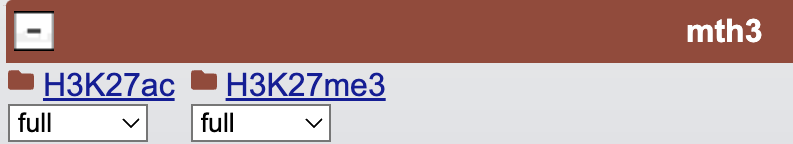

# 6 Composite *Track Hubs* with groups and subgroups

The tracks within one track group can be further organized into subgroups. This can be helpful when you have a large collection of samples, with different subsets of them having something in common. For example, a large group of tracks containing brain samples can be organized into subgroups that indicate the sample’s brain region annotation. Adding these additional subgroups can be helpful to (de)select subsets of samples and display them according to their metadata values.

Passing subgroup information to the function `easyTrackhub()` is possible by adding more columns to the input `data.frame`. Note that the `group` column needs to be present in the input `data.frame` for further subgrouping variables to be considered by the function. The column names of the subgrouping variables in the input `data.frame` must match the regular expression`subgroup[1-9]_\S+` (i.e. the word ‘subgroup’ followed by a number from 1 to 9, followed by an underscore, followed by the variable name without spaces or special characters) in order to be considered by the function `easyTrackHub()`.

```r
test_df$subgroup1_cell_type <- test_df$cell_type
test_df$subgroup2_myvariable2 <-
    rep(LETTERS[1:2], length.out=nrow(test_df))
test_df$subgroup3_myvariable3 <-
    rep(rev(LETTERS[1:5]), length.out=nrow(test_df))

easyTrackHub( test_df, trackhub_name="mth4",
             trackhub_path="mth4", maintainer_email="prueba@novartis.com" )
```

```
## Writing trackhub 'mth4' with 21 tracks organized into a main grouping variable and 3 subgrouping variables...
```

The configuration settings of each track group will contain the subgrouping variables, which one can use to select and de-select samples to show according to the subgroup labels. For example, the configuration settings of the *Track Hub ‘mth4’* created by the code above will look like this:

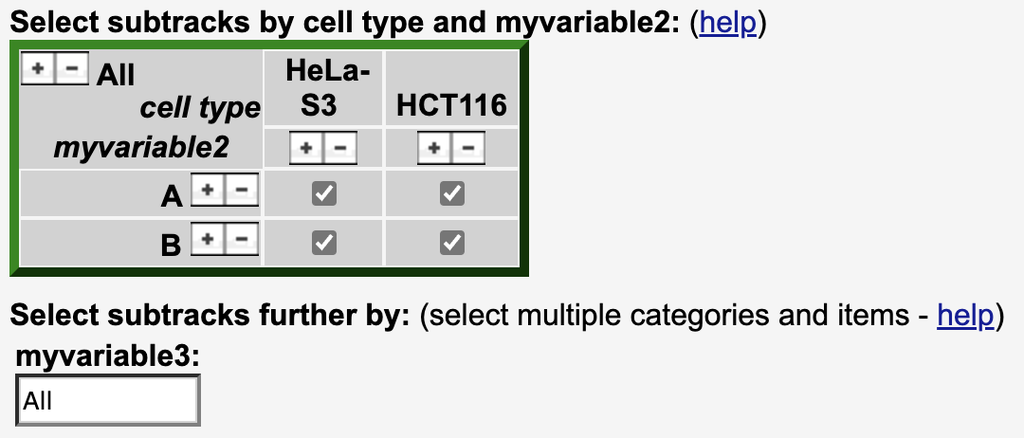